# Predictive Modeling wirh caret

Joseph Rickert

10/27/17

## Predictive Modeling with caret

`caret` (short for Classification and REgression Training) is a feature rich package for doing predictive modeling in R. It was designed to:  
* Create a unified interface for modeling and prediction (As of this date, caret includes 238 different modeling functions.)  
* Streamline the model tuning process using resampling  
* Provide a variety of “helper” functions and classes for day-to-day model building tasks  
* Increase computational efficiency by using parallel processing

`caret` provides functions to streamline the entire process and includes tools for:  
* data splitting  
* pre-processing  
* feature selection  
* model tuning using resampling  
* variable importance estimation

In this notebook we explore `caret's` capabilities by fitting three different predictive models: (1) a Generalized Boosted Regression model, (2) a Support Vector Machine, and (3) a Random Forests model). We will train each model on the same training data set and then compare their performance at making predictions on a test data set.

Along the way, we will see some of the infrastructure `caret` provides for training and tuning models, comparing multiple models and running parallels computations.

The analysis presented here is based on examples presented by Max Kuhn, caret’s author, at UseR! 2012. For more information on `caret` see the [documentation] (https://topepo.github.io/caret/available-models.html) on github.com.

### The Data

We will use the cell segmentation data, `segmentationData`, included in the package which contains 2019 rows and 61 columns. This data is described in the paper: Hill et al [Impact of image segmentation on high-content screening data quality for SK-BR-3 cells](https://bmcbioinformatics.biomedcentral.com/articles/10.1186/1471-2105-8-340) BMC bioinformatics (2007) vol 8 (1) pp. 340

### The Prediction Problem

“Well-segmented”" cells are cells for which location and size may be accurately determined through optical measurements. Cells that are not Well-segmented (WS) are said to be “Poorly-segmented”" (PS). Given a set of optical measurements can we predict which cells will be PS? This is a classic classification problem

### Packages Required

```r
library(caret) # Predictive models
library(corrplot) # plot correlations
library(doParallel) # parallel processing
library(gbm) # Boosting algorithms
library(kernlab) # Support Vector Machine
library(randomForest) # Random Forest Model
library(pROC) # plot the ROC curve
```

### Fetch and Examine the Data

Load the data and construct indices to divide it into training and test data sets.

```r
data(segmentationData)      # Load the segmentation data set
head(segmentationData)
```

|  | Cell | Case | Class | AngleCh1 | AreaCh1 | AvgIntenCh1 | AvgIntenCh2 | AvgIntenCh3 | AvgIntenCh4 | ConvexHullAreaRatioCh1 | ConvexHullPerimRatioCh1 | DiffIntenDensityCh1 | DiffIntenDensityCh3 | DiffIntenDensityCh4 | EntropyIntenCh1 | EntropyIntenCh3 | EntropyIntenCh4 | EqCircDiamCh1 | EqEllipseLWRCh1 | EqEllipseOblateVolCh1 | EqEllipseProlateVolCh1 | EqSphereAreaCh1 | EqSphereVolCh1 | FiberAlign2Ch3 | FiberAlign2Ch4 | FiberLengthCh1 | FiberWidthCh1 | IntenCoocASMCh3 | IntenCoocASMCh4 | … |
| --- | --- | --- | --- | --- | --- | --- | --- | --- | --- | --- | --- | --- | --- | --- | --- | --- | --- | --- | --- | --- | --- | --- | --- | --- | --- | --- | --- | --- | --- | --- |
| 1 | 207827637 | Test | PS | 143.247705 | 185 | 15.71186 | 4.954802 | 9.548023 | 2.214689 | 1.124509 | 0.9196827 | 29.51923 | 13.77564 | 6.826923 | 4.969781 | 4.371017 | 2.718884 | 15.36954 | 3.060676 | 336.9691 | 110.0963 | 742.1156 | 1900.996 | 1.000000 | 1.000000 | 26.98132 | 7.410365 | 0.011183899 | 0.050448005 | … |
| 2 | 207932307 | Train | PS | 133.752037 | 819 | 31.92327 | 206.878517 | 69.916880 | 164.153453 | 1.263158 | 0.7970801 | 31.87500 | 43.12228 | 79.308424 | 6.087592 | 6.642761 | 7.880155 | 32.30558 | 1.558394 | 2232.9055 | 1432.8246 | 3278.7256 | 17653.525 | 1.487935 | 1.352374 | 64.28230 | 13.167079 | 0.028051061 | 0.012594975 | … |
| 3 | 207932463 | Train | WS | 106.646387 | 431 | 28.03883 | 116.315534 | 63.941748 | 106.696602 | 1.053310 | 0.9354750 | 32.48771 | 35.98577 | 51.357050 | 5.883557 | 6.683000 | 7.144601 | 23.44892 | 1.375386 | 802.1945 | 583.2504 | 1727.4104 | 6750.985 | 1.300522 | 1.522316 | 21.14115 | 21.141150 | 0.006862315 | 0.006141691 | … |
| 4 | 207932470 | Train | PS | 69.150325 | 298 | 19.45614 | 102.294737 | 28.217544 | 31.028070 | 1.202625 | 0.8658291 | 26.73228 | 22.91732 | 26.393701 | 5.420065 | 5.436732 | 5.778329 | 19.50279 | 3.391220 | 724.7143 | 213.7031 | 1194.9320 | 3884.084 | 1.220424 | 1.733250 | 43.14112 | 7.404412 | 0.030962071 | 0.011033195 | … |
| 5 | 207932455 | Test | PS | 2.887837 | 285 | 24.27574 | 112.415441 | 20.474265 | 40.577206 | 1.109333 | 0.9568124 | 31.58065 | 21.70968 | 25.032258 | 5.658248 | 5.285671 | 5.235857 | 19.05279 | 2.741380 | 607.5185 | 221.6105 | 1140.4263 | 3621.385 | 1.491387 | 1.384547 | 34.74977 | 8.483574 | 0.022768411 | 0.079690842 | … |
| 6 | 207827656 | Test | WS | 40.748298 | 172 | 325.93333 | 653.606061 | 128.690909 | 346.854545 | 1.005831 | 0.9926363 | 92.56291 | 61.92715 | 145.708609 | 6.998111 | 6.805538 | 7.119323 | 14.83940 | 1.039726 | 176.7693 | 170.0153 | 691.8027 | 1710.989 | 1.309504 | 1.362191 | 12.38420 | 12.384199 | 0.008914083 | 0.009155300 | … |

```r
#
trainIndex <- createDataPartition(segmentationData$Case,p=.5,list=FALSE)
trainData <- segmentationData[trainIndex,-c(1,2)]
testData  <- segmentationData[-trainIndex,-c(1,2)]
#
trainX <-trainData[,-1]        # Pull out the dependent variable
testX <- testData[,-1]
```

First, we look at the relative variability of the centered and scaled predictors in the training data.

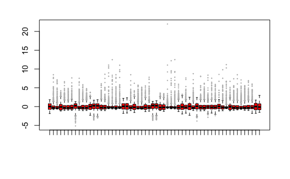

```r
scale_train <- sapply(trainX,scale)
boxplot(as.data.frame(scale_train), col="red", names=FALSE, pars=list(outcol="grey",outcex=.2))
```

Next, we plot the correlation structure of the predictor variables in the training data.

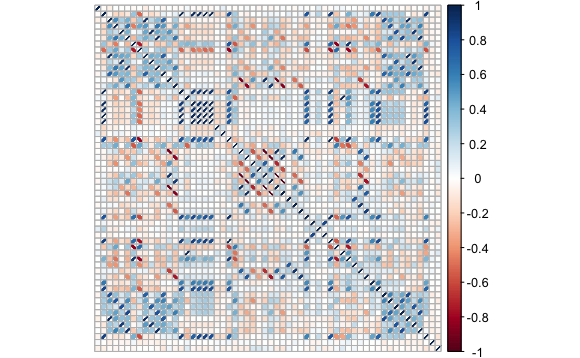

```r
corrplot(cor(trainX),
         method="ellipse",
         tl.pos = "n")
```

### Generalized Boosted Regression Model

We fit a gbm model on the training data. Note that the gbm function does not allow factor “class” variables.

```r
gbmTrain <- trainData
gbmTrain$Class <- ifelse(gbmTrain$Class=="PS",1,0)
gbm.mod <- gbm(formula = Class~.,           # use all variables
                distribution = "bernoulli",       # for a classification problem
                data = gbmTrain,
                n.trees = 2000,                         # 2000 boosting iterations
                interaction.depth = 7,              # 7 splits for each tree
                shrinkage = 0.01,                       # the learning rate parameter
                verbose = FALSE)                        # Do not print the details
```

The method for the summary command of the gbm model lists and plots out the most influential variables.

|  | var | rel.inf |
| --- | --- | --- |
| TotalIntenCh2 | TotalIntenCh2 | 20.3354925 |
| FiberWidthCh1 | FiberWidthCh1 | 11.5955513 |
| AvgIntenCh1 | AvgIntenCh1 | 3.3785544 |
| ShapeP2ACh1 | ShapeP2ACh1 | 3.0581713 |
| TotalIntenCh1 | TotalIntenCh1 | 2.9443583 |
| IntenCoocContrastCh3 | IntenCoocContrastCh3 | 2.8894225 |
| AvgIntenCh2 | AvgIntenCh2 | 2.7026384 |
| KurtIntenCh1 | KurtIntenCh1 | 2.0407426 |
| SkewIntenCh1 | SkewIntenCh1 | 1.9459834 |
| ConvexHullAreaRatioCh1 | ConvexHullAreaRatioCh1 | 1.9399873 |

[output cut: 48 more lines]

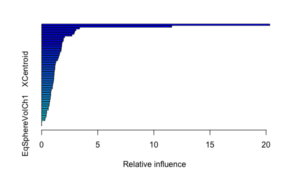

```r
summary(gbm.mod)            # Plot the relative inference of the variables in the model
```

This is an interesting model, but how do you select the best values for the for the three tuning parameters n.trees, interaction.depth and shrinkage? To answer this question we will use `caret's` `trainControl()` function which sets up a grid of parameters to be varied and implements the following algorithm to search for the best model as parameters are varied over the grid.

#### GBM Model Training Over Paramter Space

caret provides the “train” function that implements the following algorithm:

Algorithm for training the model:  
Define sets of model parameters to evaluate.

1. for each parameter set do  
   ….for each resampling iteration do  
   ……hold out specific samples  
   ……pre-process the data  
   ……fit the model to the remainder  
   ……predict the holdout samples  
   ….end  
   ….calculate the average performance across hold-out predictions  
   end
2. Determine the optimal parameter set
3. Fit the final model to the training data using the optimal parameter set.

The default method of picking the best model is accuracy and Cohen’s Kappa

```r
# Set up training control
ctrl <- trainControl(method="repeatedcv",   # 10fold cross validation
                     repeats=5,                                   # do 5 repititions of cv
                     summaryFunction=twoClassSummary,   # Use AUC to pick the best model
                     classProbs=TRUE)
```

Here, ww use the expand.grid to specify the search space. Note that the default search grid selects 3 values of each tuning parameter

```r
grid <- expand.grid(interaction.depth = seq(1,4,by=2), #tree depths from 1 to 4
                    n.trees=seq(10,100,by=10),  # let iterations go from 10 to 100
                    shrinkage=c(0.01,0.1),          # Try 2 values fornlearning rate
                    n.minobsinnode = 20)
#
set.seed(1951)          # set same seed for each model.
```

Next, we set up to to do parallel processing.

```r
registerDoParallel(4)       # Registrer a parallel backend for train
getDoParWorkers()
```

```
[1] 4
```

```r
system.time(gbm.tune <- train(x=trainX,y=trainData$Class,
                method = "gbm",
                metric = "ROC",
                trControl = ctrl,
                tuneGrid=grid,
                verbose=FALSE))
```

```
   user  system elapsed
185.001   3.349  18.455
```

Finally, we examine the tuning results. Note that ROC was the performance criterion used to select the optimal model.

```r
gbm.tune$bestTune
```

|  | n.trees | interaction.depth | shrinkage | n.minobsinnode |
| --- | --- | --- | --- | --- |
| 40 | 100 | 3 | 0.1 | 20 |

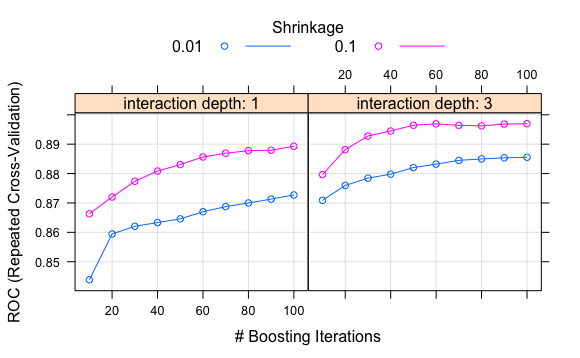

```r
plot(gbm.tune)          # Plot the performance of the training models
```

```r
res <- gbm.tune$results
names(res) <- c("depth","trees", "shrinkage","ROC", "Sens","Spec", "sdROC", "sdSens", "seSpec")
res
```

|  | depth | trees | shrinkage | ROC | Sens | Spec | sdROC | sdSens | seSpec | None |
| --- | --- | --- | --- | --- | --- | --- | --- | --- | --- | --- |
| 1 | 0.01 | 1 | 20 | 10 | 0.8438547 | 1.0000000 | 0.0000000 | 0.04383119 | 0.00000000 | 0.00000000 |
| 21 | 0.10 | 1 | 20 | 10 | 0.8663162 | 0.8993846 | 0.6027778 | 0.03922522 | 0.04078804 | 0.09804880 |
| 11 | 0.01 | 3 | 20 | 10 | 0.8708889 | 1.0000000 | 0.0000000 | 0.03667550 | 0.00000000 | 0.00000000 |
| 31 | 0.10 | 3 | 20 | 10 | 0.8796453 | 0.8855385 | 0.6750000 | 0.03481403 | 0.03834015 | 0.08175951 |
| 2 | 0.01 | 1 | 20 | 20 | 0.8594316 | 1.0000000 | 0.0000000 | 0.04225599 | 0.00000000 | 0.00000000 |
| 22 | 0.10 | 1 | 20 | 20 | 0.8720171 | 0.8744615 | 0.6750000 | 0.03715577 | 0.03773057 | 0.07861751 |
| 12 | 0.01 | 3 | 20 | 20 | 0.8759573 | 1.0000000 | 0.0000000 | 0.03656308 | 0.00000000 | 0.00000000 |
| 32 | 0.10 | 3 | 20 | 20 | 0.8881282 | 0.8735385 | 0.7277778 | 0.03327766 | 0.04079751 | 0.08093682 |
| 3 | 0.01 | 1 | 20 | 30 | 0.8620427 | 1.0000000 | 0.0000000 | 0.04066119 | 0.00000000 | 0.00000000 |
| 23 | 0.10 | 1 | 20 | 30 | 0.8773675 | 0.8726154 | 0.7133333 | 0.03415842 | 0.04041088 | 0.07305037 |

[output cut: 30 more lines]

#### GBM Model Predictions and Performance

Make predictions using the test data set, and examine the results using the “confusion matrix”"

```r
gbm.pred <- predict(gbm.tune,testX)
confusionMatrix(gbm.pred,testData$Class)
```

```
Confusion Matrix and Statistics

          Reference
Prediction  PS  WS
        PS 560  97
        WS  90 262

               Accuracy : 0.8147
                 95% CI : (0.7893, 0.8382)
    No Information Rate : 0.6442
    P-Value [Acc > NIR] : <2e-16

                  Kappa : 0.5939
 Mcnemar's Test P-Value : 0.6608

            Sensitivity : 0.8615
            Specificity : 0.7298
         Pos Pred Value : 0.8524
         Neg Pred Value : 0.7443
             Prevalence : 0.6442
         Detection Rate : 0.5550
   Detection Prevalence : 0.6511
      Balanced Accuracy : 0.7957

       'Positive' Class : PS
```

Calculate the area under the ROC curve and draw the ROC curve.

```r
gbm.probs <- predict(gbm.tune,testX,type="prob")
gbm.ROC <- roc(predictor=gbm.probs$PS,
            response=testData$Class,
                levels=rev(levels(testData$Class)))
gbm.ROC$auc
```

```
Area under the curve: 0.8962
```

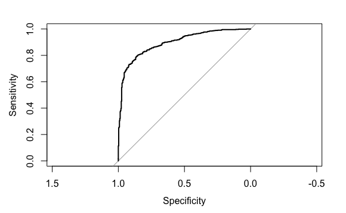

```r
plot(gbm.ROC)
```

Plot the probability of poor segmentation.

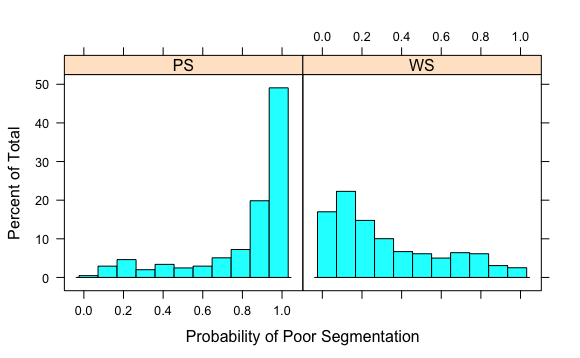

```r
histogram(~gbm.probs$PS|testData$Class,xlab="Probability of Poor Segmentation")
```

### Suport Vector Machine Model

We follow steps similar to those above to build a SVM model.

```r
# Set up for parallel procerssing
set.seed(1951)
registerDoParallel(4,cores=4)
getDoParWorkers()
```

```
[1] 4
```

Train and Tune the SVM.

```r
system.time(
  svm.tune <- train(x = trainX,
                    y = trainData$Class,
                    method = "svmRadial",
                    tuneLength = 9,                 # 9 values of the cost function
                    preProc = c("center","scale"),
                    metric = "ROC",
                    trControl=ctrl) # same as for gbm above
)
```

```
maximum number of iterations reached 9.651243e-06 2.770338e-06   user  system elapsed
357.920  15.598 118.062
```

```r
svm.tune
```

[output not shown]

Plot the SVM tuning results.

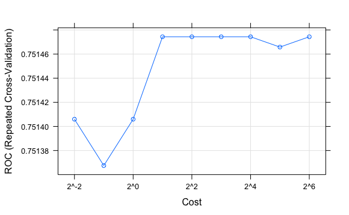

```r
plot(svm.tune,
     metric="ROC",
     scales=list(x=list(log=2)))
```

Make predictions on the test data with the SVM Model.

```r
svm.pred <- predict(svm.tune,testX)
confusionMatrix(svm.pred,testData$Class)
```

```
Confusion Matrix and Statistics

          Reference
Prediction  PS  WS
        PS 649 359
        WS   1   0

               Accuracy : 0.6432
                 95% CI : (0.6128, 0.6728)
    No Information Rate : 0.6442
    P-Value [Acc > NIR] : 0.5405

                  Kappa : -0.002
 Mcnemar's Test P-Value : <2e-16

            Sensitivity : 0.9985
            Specificity : 0.0000
         Pos Pred Value : 0.6438
         Neg Pred Value : 0.0000
             Prevalence : 0.6442
         Detection Rate : 0.6432
   Detection Prevalence : 0.9990
      Balanced Accuracy : 0.4992

       'Positive' Class : PS
```

```r
svm.probs <- predict(svm.tune,testX,type="prob")
svm.ROC <- roc(predictor=svm.probs$PS,
               response=testData$Class,
               levels=rev(levels(testData$Class)))
svm.ROC
```

```
Call:
roc.default(response = testData$Class, predictor = svm.probs$PS,     levels = rev(levels(testData$Class)))

Data: svm.probs$PS in 359 controls (testData$Class WS) < 650 cases (testData$Class PS).
Area under the curve: 0.7477
```

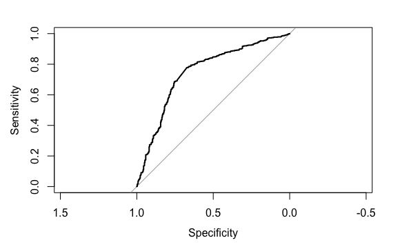

```r
plot(svm.ROC)
```

### Random Forest Model

We repeat the same procedure as in the previous two cases to build a Random Forest model.

Train the model.

```r
set.seed(1951)
rf.tune <-train(x = trainX,
                y = trainData$Class,
                method = "rf",
                trControl = ctrl,
                metric = "ROC",
                prox = TRUE,
                allowParallel = TRUE)
```

Examine the training results.

```r
rf.tune
```

```
Random Forest

1010 samples
  58 predictor
   2 classes: 'PS', 'WS'

No pre-processing
Resampling: Cross-Validated (10 fold, repeated 5 times)
Summary of sample sizes: 909, 909, 909, 909, 909, 909, ...
Resampling results across tuning parameters:

  mtry  ROC        Sens       Spec
   2    0.9015983  0.8843077  0.7472222
  30    0.9006795  0.8735385  0.7644444
  58    0.8927051  0.8695385  0.7511111

ROC was used to select the optimal model using  the largest value.
The final value used for the model was mtry = 2.
```

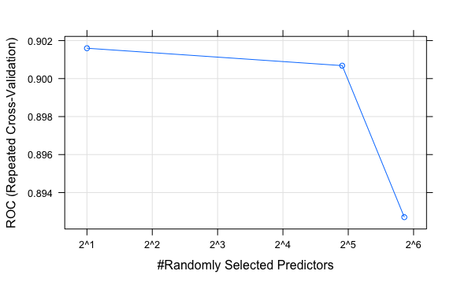

```r
# Plot the Random Forest results
plot(rf.tune,
     metric="ROC",
     scales=list(x=list(log=2)))
```

Make predictions and examine the results.

```r
# Random Forest Predictions
rf.pred <- predict(rf.tune,testX)
confusionMatrix(rf.pred,testData$Class)
```

```
Confusion Matrix and Statistics

          Reference
Prediction  PS  WS
        PS 558 101
        WS  92 258

               Accuracy : 0.8087
                 95% CI : (0.7831, 0.8326)
    No Information Rate : 0.6442
    P-Value [Acc > NIR] : <2e-16

                  Kappa : 0.5804
 Mcnemar's Test P-Value : 0.5647

            Sensitivity : 0.8585
            Specificity : 0.7187
         Pos Pred Value : 0.8467
         Neg Pred Value : 0.7371
             Prevalence : 0.6442
         Detection Rate : 0.5530
   Detection Prevalence : 0.6531
      Balanced Accuracy : 0.7886

       'Positive' Class : PS
```

```r
rf.probs <- predict(rf.tune,testX,type="prob")
rf.ROC <- roc(predictor=rf.probs$PS,
               response=testData$Class,
               levels=rev(levels(testData$Class)))
rf.ROC
```

```
Call:
roc.default(response = testData$Class, predictor = rf.probs$PS,     levels = rev(levels(testData$Class)))

Data: rf.probs$PS in 359 controls (testData$Class WS) < 650 cases (testData$Class PS).
Area under the curve: 0.8951
```

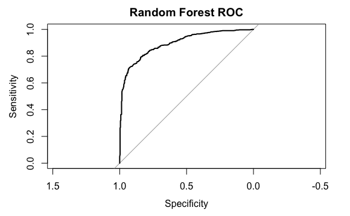

```r
plot(rf.ROC,main = "Random Forest ROC")
```

### Comparing Multiple Models

Having set the same seed before running gbm.tune, svm.tune and rf.tune we have generated paired samples are in a position to compare models using a resampling technique.we (See Hothorn et al., [The Design and Analysis of enchmark Experiments](http://ro.uow.edu.au/cgi/viewcontent.cgi?article=3494&context=commpapers) - Journal of Computational and Graphical Statistics (2005) vol 14 (3) pp 675-699).

```r
rValues <- resamples(list(svm=svm.tune,gbm=gbm.tune,rf=rf.tune))
rValues$values
```

| Resample | svm~ROC | svm~Sens | svm~Spec | gbm~ROC | gbm~Sens | gbm~Spec | rf~ROC | rf~Sens | rf~Spec |
| --- | --- | --- | --- | --- | --- | --- | --- | --- | --- |
| Fold01.Rep1 | 0.7818376 | 1.0000000 | 0.00000000 | 0.9397436 | 0.9230769 | 0.8611111 | 0.9489316 | 0.9384615 | 0.8333333 |
| Fold01.Rep2 | 0.7807692 | 1.0000000 | 0.02777778 | 0.9051282 | 0.8615385 | 0.7777778 | 0.9098291 | 0.8615385 | 0.8055556 |
| Fold01.Rep3 | 0.6942308 | 1.0000000 | 0.02777778 | 0.8965812 | 0.7692308 | 0.8888889 | 0.9083333 | 0.8000000 | 0.8333333 |
| Fold01.Rep4 | 0.7162393 | 1.0000000 | 0.02777778 | 0.8286325 | 0.8461538 | 0.6388889 | 0.8465812 | 0.8769231 | 0.6666667 |
| Fold01.Rep5 | 0.7004274 | 0.9846154 | 0.00000000 | 0.8534188 | 0.8307692 | 0.6388889 | 0.8801282 | 0.8615385 | 0.6944444 |
| Fold02.Rep1 | 0.7247863 | 1.0000000 | 0.00000000 | 0.8619658 | 0.9076923 | 0.6111111 | 0.8805556 | 0.8769231 | 0.6388889 |
| Fold02.Rep2 | 0.7047009 | 1.0000000 | 0.00000000 | 0.8598291 | 0.8000000 | 0.7500000 | 0.8782051 | 0.8461538 | 0.6944444 |
| Fold02.Rep3 | 0.8123932 | 1.0000000 | 0.02777778 | 0.8666667 | 0.8923077 | 0.7500000 | 0.8929487 | 0.8923077 | 0.7500000 |
| Fold02.Rep4 | 0.7651709 | 1.0000000 | 0.05555556 | 0.9311966 | 0.9076923 | 0.8611111 | 0.9215812 | 0.9076923 | 0.8055556 |
| Fold02.Rep5 | 0.7927350 | 1.0000000 | 0.00000000 | 0.9358974 | 0.8923077 | 0.8611111 | 0.9405983 | 0.8769231 | 0.8611111 |

[output cut: 40 more lines]

```r
summary(rValues)
```

```
Call:
summary.resamples(object = rValues)

Models: svm, gbm, rf
Number of resamples: 50

ROC
         Min.   1st Qu.    Median      Mean   3rd Qu.      Max. NA's
svm 0.6865385 0.7248932 0.7551282 0.7514744 0.7754808 0.8602564    0
gbm 0.8286325 0.8777778 0.8982906 0.8969658 0.9178419 0.9568376    0
rf  0.8326923 0.8811966 0.9049145 0.9015983 0.9199786 0.9510684    0

Sens
         Min.   1st Qu.    Median      Mean   3rd Qu.      Max. NA's
svm 0.9846154 1.0000000 1.0000000 0.9993846 1.0000000 1.0000000    0
gbm 0.7692308 0.8461538 0.8769231 0.8741538 0.9076923 0.9384615    0
rf  0.8000000 0.8615385 0.8923077 0.8843077 0.9076923 0.9538462    0

Spec
         Min.   1st Qu. Median       Mean    3rd Qu.       Max. NA's
svm 0.0000000 0.0000000   0.00 0.01555556 0.02777778 0.08333333    0
gbm 0.5277778 0.6944444   0.75 0.76000000 0.82638889 0.94444444    0
rf  0.5833333 0.6944444   0.75 0.74722222 0.80555556 0.88888889    0
```

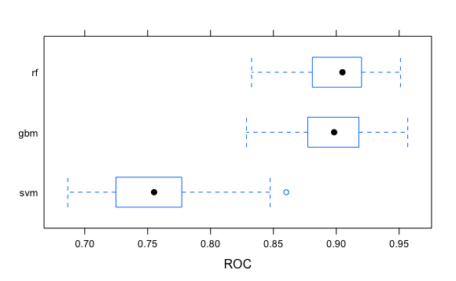

```r
bwplot(rValues,metric="ROC")            # boxplot
```

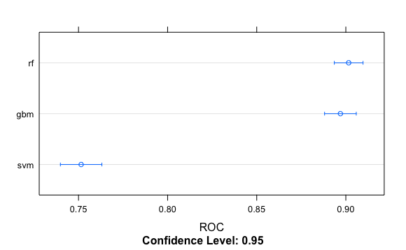

```r
dotplot(rValues,metric="ROC")           # dotplot
```

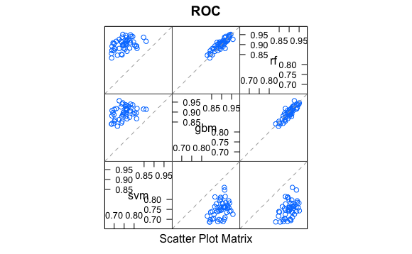

```r
splom(rValues,metric="ROC")
```

It looks like a toss up between the Random Forest and GBM.